# R Notebook

```r
library(tidyverse)
library(janitor)
library(infer)
```

```r
ames <- read_csv("data/ames.csv")
ames <- clean_names(ames)

glimpse(ames)
```

[output not shown]

Plot a histogram of lot_area. Is the distribution normal?

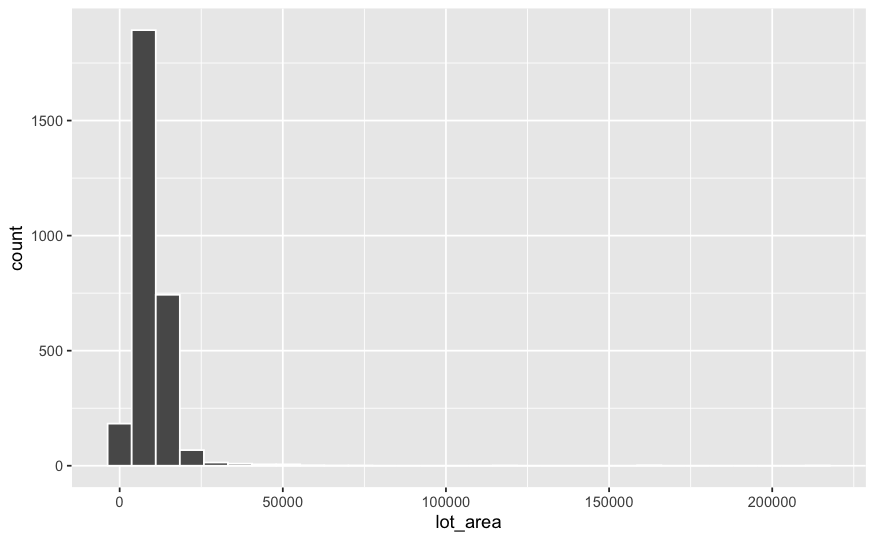

```r
ames %>%
  ggplot(aes(x = lot_area)) +
  geom_histogram(col = "white", bins = 30)
```

```r
NA
NA
```

Compute and visualise a bootstrap sampling distribution for the mean(lot_area) of the sold houses.

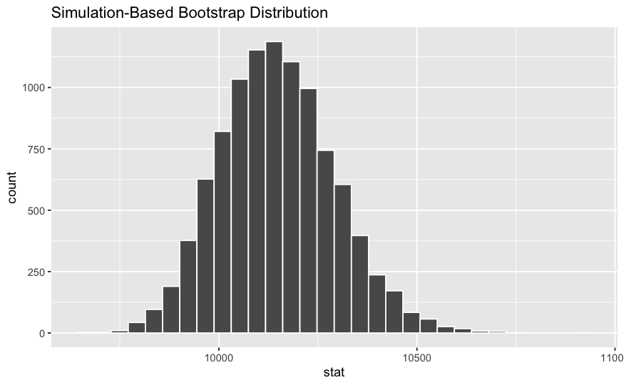

```r
bootstrap_distribution <- ames  %>%
  specify(response = lot_area) %>%
  generate(reps = 10000, type = "bootstrap") %>%
  calculate(stat = "mean")

bootstrap_distribution %>%
  visualise(bins = 30)
```

Use your bootstrap distribution to calculate a 95% CI for mean(lot_area), and visualise it on the distribution

```r
bootstrap_ci <- bootstrap_distribution %>%
  get_confidence_interval(level = 0.95, type = "percentile")

bootstrap_ci
```

| 2.5% | 97.5% |
| --- | --- |
| 9883.722 | 10451.04 |

```r
NA
NA
```

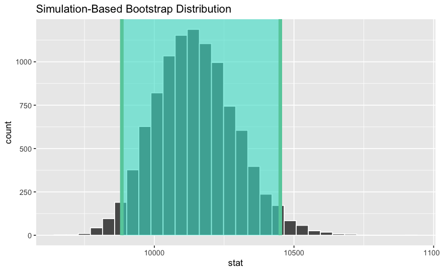

```r
bootstrap_distribution %>%
  visualise(bins = 30)+
  shade_confidence_interval(endpoints = bootstrap_ci)
```

```r
NA
NA
```

You would like to know the mean(lot_area) of the sold houses with higher confidence. Calculate the 99% CI for this variable (you can re-use your bootstrap distribution from above). Is it narrower or broader than the 95% CI? Does that make sense?

```r
bootstrap_99_ci <- bootstrap_distribution %>%
  get_confidence_interval(level = 0.99, type = "percentile")

bootstrap_99_ci
```

| 0.5% | 99.5% |
| --- | --- |
| 9812.319 | 10565.14 |

```r
NA
NA
```

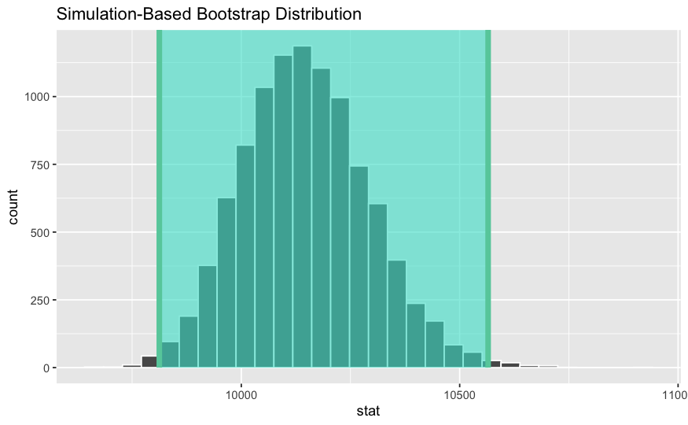

```r
bootstrap_distribution %>%
  visualise(bins = 30)+
  shade_confidence_interval(endpoints = bootstrap_99_ci)
```

Calculate the point estimate of the mean(lot_area)

```r
bootstrap_distribution %>%
  summarise(mean(stat))
```

| mean(stat) |
| --- |
| 10147.73 |

```r
NA
```

If we take 99% CI visulisation will be broader as confidence level increase so the endpoint.

2 Extension

Hint - the current implementation of calculate(stat = “prop”) in infer is slow! You can get around this by treating the mean in this way: add a new column via mutate(before_1920 = as.numeric(year_built < 1920)) and then calculate(stat = “mean”) on this new column]

```r
houses_before_1920 <- ames %>%
  mutate(before_1920 = as.numeric(year_built < 1920))
```

```r
bootstrap_distribution_1920 <- houses_before_1920  %>%
  specify(response = before_1920) %>%
  generate(reps = 50000, type = "bootstrap") %>%
  calculate(stat = "mean")
```

```r
bootstrap_95_ci <- bootstrap_distribution_1920 %>%
  get_confidence_interval(level = 0.95, type = "percentile")

bootstrap_95_ci
```

| 2.5% | 97.5% |
| --- | --- |
| 0.05153584 | 0.06894198 |

```r
NA
```